# Practical Machine Learning - Prediction Assignment Writeup

## Objective

The goal of this project is to predict the manner in which they did the exercise. This is the “classe” variable in the training set. You may use any of the other variables to predict with. You should create a report describing how you built your model, how you used cross validation, what you think the expected out of sample error is, and why you made the choices you did. You will also use your prediction model to predict 20 different test cases.

## Gathering Data

The following r package is required to execute this r code in this project.

```r
# install.packages("caret")
# install.packages("e1071")
# install.packages("randomForest")
# install.packages("rattle")

library("caret")
library("e1071")
library("randomForest")
library("rattle")
```

- Load csv data from files downloaded into project directory

```r
# load data, noticed that we have a lot of #DIV/0!, we convert them to NA
training <- read.csv("./pml-training.csv", row.names = 1, na.strings=c("#DIV/0!"))
testing <- read.csv("./pml-testing.csv", row.names = 1, na.strings=c("#DIV/0!"))
```

- Identify zero/near zero variance predictors, prepare for removal

```r
nzv_result <- nearZeroVar(training, saveMetrics = T)
training <- training <- training[, !nzv_result$nzv]
```

- Remove variables with more than 80% NA values

```r
nav <- sapply(colnames(training), function(x) if(sum(is.na(training[, x])) > 0.8*nrow(training)){return(T)}else{return(F)})
training <- training[, !nav]
```

- Calculate correlations

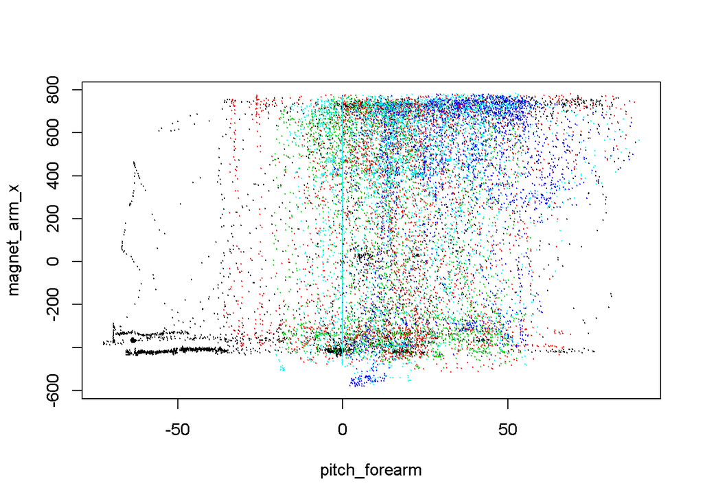

```r
cor <- abs(sapply(colnames(training[, -ncol(training)]), function(x) cor(as.numeric(training[, x]), as.numeric(training$classe), method = "spearman")))
plot(training[, names(which.max(cor))], training[, names(which.max(cor[-which.max(cor)]))], col = training$classe, pch = 19, cex = 0.1, xlab = names(which.max(cor)), ylab = names(which.max(cor[-which.max(cor)])))
```

No strong correlation from predictors to classes was observed, so linear regression model is probably not suitable in this case.

## Model Construction

As linear regression is not suitable, I used a random forest model (provided in randomForest R package) as our model. It’s consider as one of the top 2 performing algorithms so it should be good enough for the purpose of this assignment. The real drawback is it run really slow on my machine but machine time is what I have to spare.

- Fit model with random forests algorithm and 10-fold **cross validation** to predict `classe` with all other predictors.

```r
set.seed(123)
rfFit <- train(classe ~ ., method = "rf", data = training, importance = T, trControl = trainControl(method = "cv", number = 10))

rfFit
```

```
## Random Forest
##
## 19622 samples
##    57 predictor
##     5 classes: 'A', 'B', 'C', 'D', 'E'
##
## No pre-processing
## Resampling: Cross-Validated (10 fold)
##
## Summary of sample sizes: 17660, 17661, 17659, 17660, 17658, 17660, ...
##
## Resampling results across tuning parameters:
##
##   mtry  Accuracy  Kappa  Accuracy SD  Kappa SD
##    2    0.991     0.989  0.002725     0.003447
##   40    1.000     0.999  0.000526     0.000666
##   79    0.999     0.999  0.000492     0.000623
##
## Accuracy was used to select the optimal model using  the largest value.
## The final value used for the model was mtry = 40.
```

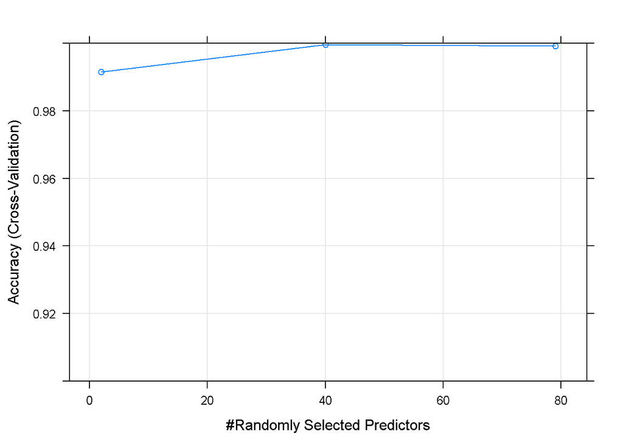

```r
plot(rfFit, ylim = c(0.9, 1))
```

- The random forests algorithm generated a very accurate model with **accuracy close to 1**.
- The final random forests model contains 500 trees with 40 variables tried at each split. The five most important predictors in this model are “raw_timestamp_part_1”, “roll_belt”, “num_window”, “pitch_forearm”, “cvtd_timestamp30/11/2011 17:12”.

```r
rownames(imp)[1:5]
```

```
## [1] "raw_timestamp_part_1"           "roll_belt"
## [3] "num_window"                     "pitch_forearm"
## [5] "cvtd_timestamp30/11/2011 17:12"
```

- Estimated **out of sample error rate** for the random forests model is **0.04%** as reported by this model;

## Prediction

```r
# final model
rfFit$finalModel
```

```
##
## Call:
##  randomForest(x = x, y = y, mtry = param$mtry, importance = ..1)
##                Type of random forest: classification
##                      Number of trees: 500
## No. of variables tried at each split: 40
##
##         OOB estimate of  error rate: 0.04%
## Confusion matrix:
##      A    B    C    D    E  class.error
## A 5580    0    0    0    0 0.0000000000
## B    1 3796    0    0    0 0.0002633658
## C    0    3 3419    0    0 0.0008766803
## D    0    0    1 3214    1 0.0006218905
## E    0    0    0    1 3606 0.0002772387
```

```r
# prediction
prediction <- as.character(predict(rfFit, testing))
```

```r
# write prediction files
pml_write_files = function(x){
  n = length(x)
  for(i in 1:n){
    filename = paste0("problem_id_", i, ".txt")
    write.table(x[i], file = filename, quote = FALSE, row.names = FALSE, col.names = FALSE)
  }
}
pml_write_files(prediction)
```